# Efficient semiparametric estimation of marginal treatment effects with genetic instrumental variables

Ashish Patel, Francis J. DiTraglia & Stephen Burgess

February 2026

$$\\$$

#### Overview

The marginal treatment effects (MTE) framework allows us to study heterogeneity in causal effects when individuals self-select into a binary treatment. Rather than assuming a constant effect, the framework estimates how the average effect varies across individuals with different unobserved propensities to receive treatment

The MTE framework identifies the marginal treatment effect using an instrumental variable that shifts treatment participation. Conventional causal estimands, such as the average treatment effect or the treatment effect on the treated, can then be expressed as weighted averages of the MTE, providing a unified way to understand how selection into treatment relates to treatment effect heterogeneity.

$$\\$$

#### Efficient Estimation

The conventional approach to estimation in the MTE framework uses a simple linear regression and does not account for uncertainty in first-stage propensity score estimation. When the instrument induces only limited variation in treatment, the estimated propensity score is concentrated over a narrow range, leading to poor estimation of the marginal treatment effects curve. These conventional estimates of target estimands will not be robust nor efficient.

For improved estimation in the MTE framework with genetic instruments, we propose using semiparametrically efficient estimates of target estimands under plug-in propensity scores. Importantly, these efficient estimates have low variance, and are robust to sampling uncertainty in the estimated propensity score. One of the benefits of this robustness property is that MTE estimation will be more robust to weak instruments. In our linear model, calculating efficient estimates and their standard errors is computationally straightforward.

$$\\$$

#### Simulation Exercise: Generalized Roy Model

We illustrate use of the efficient.mte R package with a simple simulation exercise. In the generalized Roy model discussed in the paper, we set the following parameters:

```r
# Roy Model parameters
alpha0 = 0.3 # constant level of Y0
alpha1 = 0.5 # constant level of Y1
beta0 = 0.1 # covariate effect on Y0
beta1 = 0.2 # covariate effect on Y1
delta = c(0,-0.2,0.3) # how a constant, covariates, and instrument affects the probability of treatment
rho = 0.2 # correlation of random errors of potential outcomes
zeta0 = -0.3; zeta1 = 0.3 # linear effect of V on potential outcomes
xi0=-0.3; xi1=0.1 # linear effect of X*V on potential outcomes
Sig <- matrix(c(1,rho,rho,1),2,2)*0.2 # variance matrix of random errors of potential outcomes
```

Compared to the model in the main paper, we have considered a slightly more general model outlined in the supplementary material, which allows the marginal treatment effect function to have X*V interactions. The parameters that relate to this interaction effect are $\xi_0$ and $\xi_1$.

We now simulate some data from this model:

```r
# generate data
set.seed(1)
n = 20000 # sample size
E <- mvtnorm::rmvnorm(n=n,mean=rep(0,nrow(Sig)),sigma=Sig)
V <- runif(n,0,1) # individual-level heterogeneity
X <- rbinom(n,1,0.5); X <- as.matrix(X) # a binary covariate
Z <- rnorm(n,0,1) # continuous instrument
V.poly <- function(i){(V^i)-(1/(i+1))}; V.poly <- sapply(1:length(zeta0),V.poly)
U0 = as.vector((0.2*E[,1])+(V.poly%*%zeta0)+(X*V.poly%*%xi0)) # potential outcome error under no treatment
U1 = as.vector((0.2*E[,2])+(V.poly%*%zeta1)+(X*V.poly%*%xi1)); rm(E) # potential outcome error under treatment
Y0 = as.vector(alpha0+(X%*%beta0)+U0) # potential outcome under no treatment
Y1 = as.vector(alpha1+(X%*%beta1)+U1) # potential outcome under treatment
A = 1*(pnorm(as.vector(cbind(1,X,Z)%*%delta)) > V) # treatment indicator generated from probit model
Y = (1-A)*Y0 + A*Y1 # observed outcome
```

In the above, we have a single binary covariate $X$ and a continuous instrument $Z$.

```r
# propensity score estimation
ps <- as.vector(glm(A~X+Z, family = binomial(link = "probit"))$fitted.values)
```

A probit model was used to generate the treatment indicator, and therefore we estimate the propensity scores using probit regression.

```r
# oracle values of treatment effect estimands
ate=mean(Y1-Y0)
att=mean((Y1-Y0)[A==1])
atu=mean((Y1-Y0)[A==0])
asg=att-atu
```

In practice, we would not be able to observe the both potential outcomes $Y_1$ and $Y_0$ for each individual. However, to judge the accuracy of our estimates, here we note the oracle values of the treatment effect estimands that we are interested in.

In particular, we note the average treatment effect is positive

```r
# oracle ATE value
round(c(ate),3)
```

```
## [1] 0.249
```

so that if a higher value of the outcome variable is favourable, then taking the treatment results in better outcomes on average over the population.

We also note the average selection on gain estimand is negative

```r
# oracle ASG value
round(c(asg),3)
```

```
## [1] -0.383
```

so that there is “reverse selection on gains”: those who are reluctant to take treatment are those that would benefit more from taking the treatment.

$$\\$$

#### Estimating Heterogeneous Treatment Effects

To install the efficient.mte R package, run the code

```r
# install efficient.mte R package
devtools::install_github("ash-res/efficient.mte")
```

in your R console. Then, we load the library and first estimate a simple linear MTE model that wrongly assumes the effects of the covariate $X$ and unobserved reluctance to take treatment $V$ are separable.

```r
# load library
library(efficient.mte)

# compute results under a linear MTE model assuming separable X and V effects
res <- eff.mte(A,X,Y,Z,ps,S=1,interaction=FALSE)
```

```
##
## MTE model: X and V have separable effects
##
## ---------------Efficient Target Parameter Estimates---------------
##  param estimate std err 95% CI lower 95% CI upper
##    ATE    0.229   0.008        0.214        0.245
##    ATT    0.051   0.026        0.000        0.101
##    ATU    0.387   0.026        0.335        0.439
##    ASG   -0.336   0.050       -0.434       -0.239
## ------------------------------------------------------------------
```

Note that the argument S in the eff.mte function selects the order of polynomial model used for the MTE, so that by selecting S=1 we are estimating a linear model. The logical argument interaction is set to FALSE which means the MTE model assumes separable $X$ and $V$ effects.

The ATE estimate and the ASG estimate are quite far away from their oracle values.

Now lets estimate a quadratic MTE model and again wrongly assume the effects of the covariate $X$ and unobserved reluctance to take treatment $V$ are separable.

```r
# compute results under a quadratic MTE model assuming separable X and V effects
res <- eff.mte(A,X,Y,Z,ps,S=2,interaction=FALSE)
```

```
##
## MTE model: X and V have separable effects
##
## ---------------Efficient Target Parameter Estimates---------------
##  param estimate std err 95% CI lower 95% CI upper
##    ATE    0.151   0.062        0.029        0.272
##    ATT   -0.024   0.067       -0.155        0.108
##    ATU    0.304   0.066        0.174        0.434
##    ASG   -0.328   0.049       -0.424       -0.232
## ------------------------------------------------------------------
```

Now we see the ATE estimate and the ASG estimate are even further away from their oracle values.

Finally, lets estimate the correct specification, a linear MTE model with a $X \times V$ interaction effect. In this interaction model, the MTE slope-in-V and its intercept can be different across covariates (e.g. for men and women). The output gives the efficient MTE $\gamma$ parameter estimates that allow you to plot these different MTE slopes across covariates.

```r
# compute results under a quadratic MTE model assuming separable X and V effects
res <- eff.mte(A,X,Y,Z,ps,S=1,interaction=TRUE)
```

```
##
## MTE model: X and V have interaction effects
##
## ---------------Efficient Target Parameter Estimates---------------
##  param estimate std err 95% CI lower 95% CI upper
##    ATE    0.237   0.009        0.220        0.254
##    ATT    0.052   0.025        0.003        0.101
##    ATU    0.400   0.028        0.346        0.455
##    ASG   -0.348   0.051       -0.448       -0.249
## ------------------------------------------------------------------
```

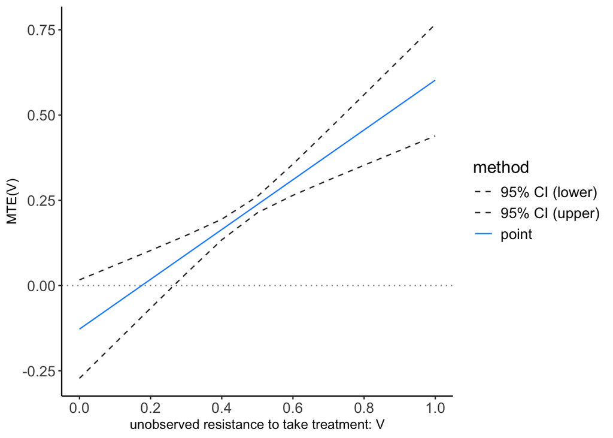

```r
# plot MTE curve
res$plot
```

Instead, the plot option in the output gives the MTE curve varying only with $V$ and averaged over the covariate $X$. This is so that it produces a standard comparable plot when selecting either interaction=FALSE or interaction=TRUE models in the eff.mte function.

From this plot, we can see that the treatment effect is increasing in unobserved resistance to take treatment $V$, which is consistent with a negative estimated ASG.